# [1] Sepsis: WHO AWaRe QIs analysis against gPPS data

CNPI AMR

Last compiled on Sunday 05 October, 2025

# 📊 Report Overview

This report presents a summary of the AWaRe-based quality indicator analysis based on gPPS inpatient data for Sepsis.

This analytical script implements **WHO AWaRe (Access, Watch, Reserve)** antibiotic use **quality indicators (QIs)** for treating **undifferentiated sepsis** in adult inpatients with **community-acquired infections (CAIs)**. It utilises standardised data from the Global PPS (gPPS), specifically extracted from Excel-based outputs received by participating hospitals.

**Clinical Sepsis of Unknown Origin** (Based on WHO AWaRe book)  
▸ **gPPS diagnostic code:** `SEPSIS`  
▸ **gPPS definition:** Sepsis of any origin (e.g., urosepsis, pulmonary sepsis, etc.), sepsis syndrome, or septic shock with no clear anatomic site, including candidemia with septic symptoms.

The aim is to assess the appropriateness of **empirical antibiotic prescribing** for sepsis, benchmarked against WHO AWaRe guidance, and to provide structured feedback at both the hospital and ward levels. These insights support **antimicrobial stewardship efforts** by highlighting patterns of suboptimal prescribing and identifying opportunities for targeted quality improvement.

## 🎯 WHO AWaRe QIs for Sepsis

Within the gPPS data structure, **two QIs** have been identified as applicable for evaluating sepsis-related empirical antibiotic prescriptions in adults with CAIs:

**Case Definition:**

1. **H_SEP_APPROP_ABX**: Proportion of patients presenting with clinical sepsis of unknown origin given the appropriate IV antibiotics according to the *WHO AWaRe Book*.
2. **H_SEP_APPROP_DOSAGE**: Proportion of patients presenting with clinical sepsis of unknown origin prescribed the total daily dose of IV empiric antibiotics recommended in the *WHO AWaRe Book*.

## 💬 General Notes:

- Analysis includes only **adult patients (≥18 years)** with **CAIs** on **empirical** treatment.
- **Intravenous (IV) administration** was inferred using the gPPS `"Route"` code `"P"` (Parenteral), recognizing that it may include other parenteral routes but predominantly indicates IV use in empirical clinical practice.
- QIs were mapped and interpreted based on clinical assumptions aligning WHO guidance with available gPPS diagnostic codes.

💡 **Reminder:** Caution is advised when interpreting results from small sample sizes (<10 patients)

# 🔍 Initial Eligible Cases Check

This section assesses whether there are enough eligible cases to support meaningful analysis.

**📅 Survey period:** 01 Feb 2025 to 05 Feb 2025

This script applies **WHO AWaRe Quality Indicators** to adult inpatients with empirical antibiotics for community-acquired sepsis.

- **Diagnostic code:** SEPSIS (Clinical Sepsis of Unknown Origin)
- **Total eligible cases:** 48

**✅ Good to go!** Sufficient eligible cases available to proceed with full evaluation.

# 🧾 Summary of Sepsis Eligible Patients for QI Assessment

Eligible patients for **WHO AWaRe Quality Indicator (QI)** assessment are defined as **adult inpatients (≥18 years)** who received **empirical antibiotics** for **CA-SEPSIS**.

This section presents both **prescription-level** and **patient-level** summaries to establish how much of the dataset is relevant for QI evaluation. It helps frame the proportion of all prescriptions that are relevant to CA-sepsis.

## 👥 Patient-Level Summary

This table reports on unique patients in each eligibility group. It reflects the clinical burden of sepsis and the proportion of patients suitable for QI evaluation.

**📊 Summary:**  
Total number of patients on antibiotics: **205**  
Total number of eligible patients on antibiotics: **48**

| Patient Category | Number of Patients | Proportion of All Patients |
| --- | --- | --- |
| Number of adult patients (≥18 years) who received empirical antibiotic treatment for CAI | 132 | 64.4% |
| Number of all patients with a diagnosis of sepsis on any antibiotics | 59 | 28.8% |
| **Number of eligible patients:** Adult patients (≥18 years) with a diagnosis of CA-Sepsis who were treated empirically with antibiotics | 48 | 23.4% |

## 📑 Prescription-Level Summary

**📊 Summary:**  
Total number of antibiotic prescriptions: **215**  
Total number of eligible antibiotic prescriptions: **49**

| Prescription Category | Number of Prescriptions | Proportion of All Prescriptions |
| --- | --- | --- |
| Number of empirical antibiotic prescriptions administered to adult patients (≥18 years) for CAI | 140 | 65.1% |
| Number of all antibiotic prescriptions for patients diagnosed with sepsis | 60 | 27.9% |
| **Number of eligible antibiotic prescriptions:** antibiotics empirically prescribed for adult patients (≥18 years) with CA-Sepsis | 49 | 22.8% |

# 📘 WHO AWaRe-QIs Overview

This section evaluates two indicators:

1. **H_SEP_APPROP_ABX**: Proportion of patients presenting with clinical sepsis of unknown origin given the appropriate IV antibiotics according to the *WHO AWaRe Book*.
2. **H_SEP_APPROP_DOSAGE**: Proportion of patients presenting with clinical sepsis of unknown origin prescribed the total daily dose of IV empiric antibiotics recommended in the *WHO AWaRe Book*.

**🔍 WHO AWaRe Book Recommendation:**

**Primary IV antibiotics:** Cefotaxime (2 g q8h) *OR* Ceftriaxone (2 g q24h)  
**Secondary IV antibiotics:** Amikacin (15 mg/kg q24h) *OR* Gentamicin (5 mg/kg q24h)  
**The recommended regimen** : A combination of one primary + one secondary antibiotic

**📘 WHO AWaRe Notes:**

- Bacteraemia is not part of the definition of sepsis. While many patients with sepsis have bacteraemia, most patients with bacteraemia do not fulfill sepsis criteria.
- Bacteria, viruses, fungi, and protozoa can cause sepsis (only sepsis of bacterial origin is addressed here).
- Start IV antibiotics as soon as possible if sepsis is suspected. Test results should not delay antibiotics.
- To choose the best empiric treatment, consider the most likely infection site and pathogens, local prevalence of resistance, comorbidities, and risk of multidrug-resistant organisms.
- Narrow empiric treatment based on culture results or clinical improvement.
- Step down to oral treatment is based on improvement of symptoms, signs of infection, and the ability to take oral antibiotics.
- Amikacin (and to a lesser extent gentamicin) retain activity against ESBL-producing strains and can be considered a carbapenem-sparing option.
- All dosages recommended in the AWaRe Book are based on normal renal function.

# 📌 Indicator 1 – IV Antibiotic Choice Appropriateness

> **H_SEP_APPROP_ABX:** Proportion of patients presenting with clinical sepsis of unknown origin given the appropriate IV antibiotics according to the WHO AWaRe Book.

## 📈 Antibiotic Choice Appropriateness for Sepsis

This visual summarises the proportion of treatment appropriateness for sepsis across hospital departments based on WHO AWaRe Book

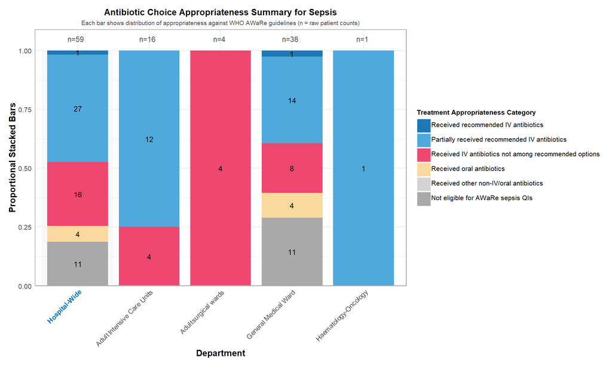

## 📝 Summary of Antibiotic Choice Appropriateness for Sepsis

This section assesses whether adult inpatients with CA-sepsis were prescribed the appropriate empirical IV antibiotic regimen based on the WHO AWaRe Antibiotic Book.

💉 **Denominator:** Number of eligible patients who received any IV antibiotics for sepsis (**44** out of **48**).

**Summary:**

**🏥 Hospital-Wide** (n = 44 patients)

- ✅ **Received recommended IV antibiotics** (as per WHO AWaRe Book): **2.3%** (1 out of 44)
- ⚠️ **Partially received recommended IV antibiotics** (as per WHO AWaRe Book): **61.4%** (27 out of 44)
- ❌ **Received IV antibiotics not among recommended options** (as per WHO AWaRe Book): **36.4%** (16 out of 44)

**🏥 Adult Intensive Care Units** (n = 16 patients)

- ✅ **Received recommended IV antibiotics** (as per WHO AWaRe Book): **0.0%** (0 out of 16)
- ⚠️ **Partially received recommended IV antibiotics** (as per WHO AWaRe Book): **75.0%** (12 out of 16)
- ❌ **Received IV antibiotics not among recommended options** (as per WHO AWaRe Book): **25.0%** (4 out of 16)

**🏥 Adult surgical wards** (n = 4 patients)

- ✅ **Received recommended IV antibiotics** (as per WHO AWaRe Book): **0.0%** (0 out of 4)
- ⚠️ **Partially received recommended IV antibiotics** (as per WHO AWaRe Book): **0.0%** (0 out of 4)
- ❌ **Received IV antibiotics not among recommended options** (as per WHO AWaRe Book): **100.0%** (4 out of 4)

**🏥 General Medical Ward** (n = 23 patients)

- ✅ **Received recommended IV antibiotics** (as per WHO AWaRe Book): **4.3%** (1 out of 23)
- ⚠️ **Partially received recommended IV antibiotics** (as per WHO AWaRe Book): **60.9%** (14 out of 23)
- ❌ **Received IV antibiotics not among recommended options** (as per WHO AWaRe Book): **34.8%** (8 out of 23)

**🏥 Haematology-Oncology** (n = 1 patients)

- ✅ **Received recommended IV antibiotics** (as per WHO AWaRe Book): **0.0%** (0 out of 1)
- ⚠️ **Partially received recommended IV antibiotics** (as per WHO AWaRe Book): **100.0%** (1 out of 1)
- ❌ **Received IV antibiotics not among recommended options** (as per WHO AWaRe Book): **0.0%** (0 out of 1)

**💡 Note:**

- **The partially recommended category** refers to cases where patients received only part of the recommended antibiotic regimen. This could mean just one of the two recommended antibiotics was given, or the recommended antibiotics were combined with others not part of the regimen.
- Secondary antibiotics (**Amikacin** or **Gentamicin**) are recommended to be used in combination with primary agents (**Cefotaxime** or **Ceftriaxone**) to achieve bactericidal synergy, broaden the spectrum of treatment activity, prevent the emergence of resistance, and induce a lasting inhibition of bacterial growth.

# 📌 Indicator 2 – IV Antibiotic Dosage Appropriateness

> **H_SEP_APPROP_DOSAGE:** Proportion of patients presenting with clinical sepsis of unknown origin prescribed the total daily dose of IV empiric antibiotics recommended in the WHO AWaRe Antibiotic Book.

## 📈 Antibiotic Choice & Dosage Appropriateness for Sepsis

This visual summarises choice & dosage appropriateness for sepsis across hospital departments based on WHO AWaRe Book

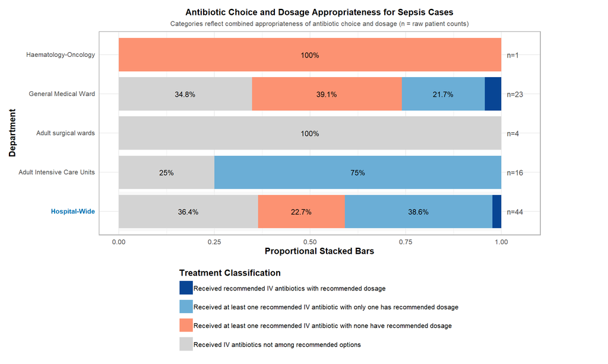

**💡 Notes:**

- **Received recommended IV antibiotics with recommended dosage** indicates that the full recommended treatment regimen was given, with both dosages aligned with WHO AWaRe Book guidance.
- **Received at least one recommended IV antibiotic with one has recommended dosage** refers to cases where only part of the recommended dual therapy was given, and only one antibiotic was at the recommended dosage.
- **Received at least one recommended IV antibiotic with none have recommended dosage** includes cases who received either the full recommended regimen with no recommended dosages, or only part of it (e.g., one agent from the dual therapy) with none of the dosages aligned with WHO AWaRe Book guidance.

## 📝 Summary of Antibiotic Choice & Dosage Appropriateness for sepsis

This section evaluates the **appropriateness of IV antibiotic drug dosage** for patients with CA-sepsis, in line with the WHO AWaRe Book

💊 **Denominator:** Number of eligible sepsis patients who received recommended (*or partially recommended*) IV antibiotic choice based on WHO AWaRe Book (**28** out of 48)

**Summary:**

**🏥 Hospital-Wide** (n = 28 patients)

- ✅ **Received recommended IV antibiotics with recommended dosage** (as per WHO AWaRe Book): **3.6%** (1 out of 28)
- ⚠️ **Received at least one recommended IV antibiotic with only one has recommended dosage** (as per WHO AWaRe Book): **60.7%** (17 out of 28)
- ❌ **Received at least one recommended IV antibiotic with none have recommended dosage** (as per WHO AWaRe Book): **35.7%** (10 out of 28)

**🏥 Adult Intensive Care Units** (n = 12 patients)

- ✅ **Received recommended IV antibiotics with recommended dosage** (as per WHO AWaRe Book): **0.0%** (0 out of 12)
- ⚠️ **Received at least one recommended IV antibiotic with only one has recommended dosage** (as per WHO AWaRe Book): **100.0%** (12 out of 12)
- ❌ **Received at least one recommended IV antibiotic with none have recommended dosage** (as per WHO AWaRe Book): **0.0%** (0 out of 12)

**🏥 Adult surgical wards** (n = 0 patients)

- ✅ **Received recommended IV antibiotics with recommended dosage** (as per WHO AWaRe Book): **0.0%** (0 out of 0)
- ⚠️ **Received at least one recommended IV antibiotic with only one has recommended dosage** (as per WHO AWaRe Book): **0.0%** (0 out of 0)
- ❌ **Received at least one recommended IV antibiotic with none have recommended dosage** (as per WHO AWaRe Book): **0.0%** (0 out of 0)

**🏥 General Medical Ward** (n = 15 patients)

- ✅ **Received recommended IV antibiotics with recommended dosage** (as per WHO AWaRe Book): **6.7%** (1 out of 15)
- ⚠️ **Received at least one recommended IV antibiotic with only one has recommended dosage** (as per WHO AWaRe Book): **33.3%** (5 out of 15)
- ❌ **Received at least one recommended IV antibiotic with none have recommended dosage** (as per WHO AWaRe Book): **60.0%** (9 out of 15)

**🏥 Haematology-Oncology** (n = 1 patients)

- ✅ **Received recommended IV antibiotics with recommended dosage** (as per WHO AWaRe Book): **0.0%** (0 out of 1)
- ⚠️ **Received at least one recommended IV antibiotic with only one has recommended dosage** (as per WHO AWaRe Book): **0.0%** (0 out of 1)
- ❌ **Received at least one recommended IV antibiotic with none have recommended dosage** (as per WHO AWaRe Book): **100.0%** (1 out of 1)